# Onyango_HW2_9.4.21

Brenda Onyango

9/2/2021

## Homework 2

## PS 02: Data Visualization

Before beginning the exercises I confirmed installation of and loaded several packages.

```r
library(dplyr)
```

```r
library(ggplot2)
library(readr)
```

### Next I will load the dataset on births in NC.

```r
nc <- read_csv("https://docs.google.com/spreadsheets/d/e/2PACX-1vTm2WZwNBoQdZhMgot7urbtu8eG7tzAq-60ZJsQ_nupykCAcW0OXebVpHksPWyR4x8xJTVQ8KAulAFS/pub?gid=202410847&single=true&output=csv")
```

I will use glimpse to view the file.

```r
glimpse(nc)
```

```
## Rows: 800
## Columns: 13
## $ fage           <dbl> 19, 21, 18, 17, 20, 30, 21, 14, 16, 20, 18, 20, 20, 26,…
## $ mage           <dbl> 15, 15, 15, 15, 16, 16, 16, 16, 16, 17, 17, 17, 17, 17,…
## $ mature         <chr> "younger mom", "younger mom", "younger mom", "younger m…
## $ weeks          <dbl> 37, 41, 37, 35, 37, 45, 38, 40, 24, 40, 37, 40, 39, 38,…
## $ premie         <chr> "full term", "full term", "full term", "premie", "full …
## $ visits         <dbl> 11, 6, 12, 5, 13, 9, 15, 12, 5, 8, 10, 17, 9, 11, 10, 1…
## $ marital        <chr> "married", "married", "married", "married", "married", …
## $ gained         <dbl> 38, 34, 76, 15, 52, 28, 75, 9, 12, 20, 39, 38, 36, 30, …
## $ weight         <dbl> 6.63, 8.00, 8.44, 4.69, 6.94, 7.44, 7.56, 5.81, 1.50, 8…
## $ lowbirthweight <chr> "not low", "not low", "not low", "low", "not low", "not…
## $ gender         <chr> "female", "male", "male", "male", "female", "male", "fe…
## $ habit          <chr> "nonsmoker", "nonsmoker", "nonsmoker", "nonsmoker", "no…
## $ whitemom       <chr> "white", "white", "not white", "not white", "white", "w…
```

I will try to use the help feature to understand the meaning of the columns.

```r
?nc
```

```
## No documentation for 'nc' in specified packages and libraries:
## you could try '??nc'
```

This attempt to use the help function gave the output "No documentation for ‘nc’ in specified packages and libraries. I will return to troubleshoot this at another time.

### Exercise 1

Habit is a character variable and visits is a double value variable meaning I can expect decimals.

#### Preparing for Exercises 2-5

For the next exercises I first set the data frame to nc.

```r
data = nc
```

Then I use ggplot to create a scatterplot of weeks on x axis and weight on y axis to explore the relationship between pregnancy length and birth weight.

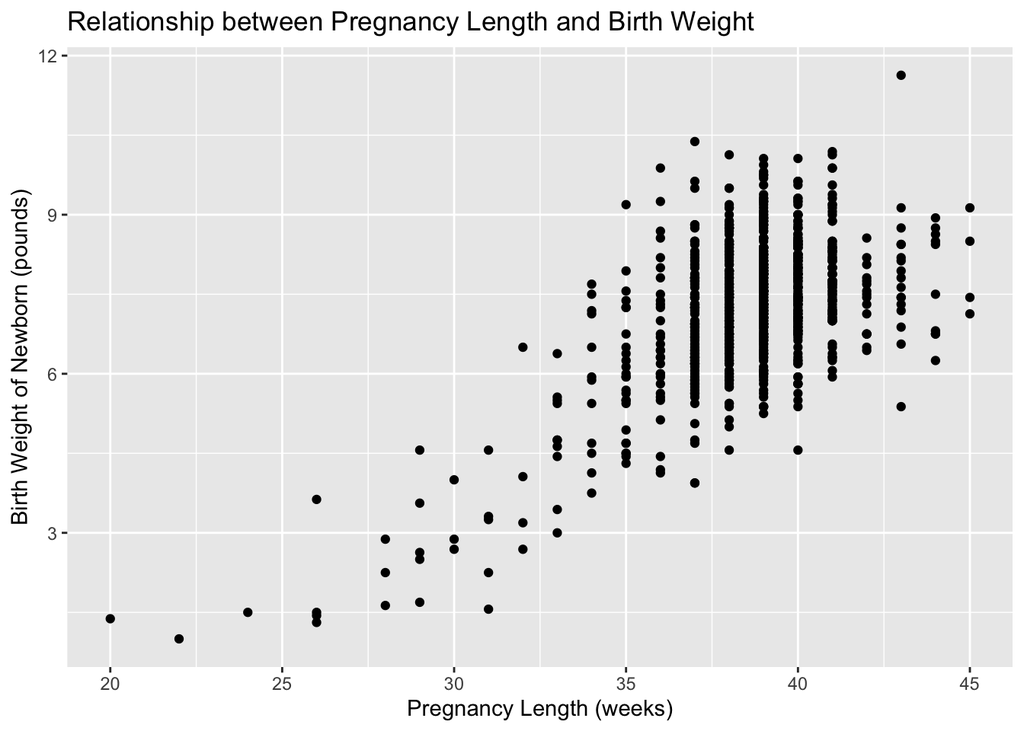

```r
ggplot(data = nc, aes(x=weeks, y = weight)) +
  geom_point() +
  labs( x = "Pregnancy Length (weeks)", y = "Birth Weight of Newborn (pounds)", title = "Relationship between Pregnancy Length and Birth Weight")
```

### Exercise 2

There is a positive relationship between the length of pregnancy and newborns’ birth weight. As pregnancy lengths increase, birth weights increase.

### Exercise 3

For this exercise I will create and run a code to graph pregnancy length in weeks on the x-axis and weight gained by the pregnant person on the y-axis.

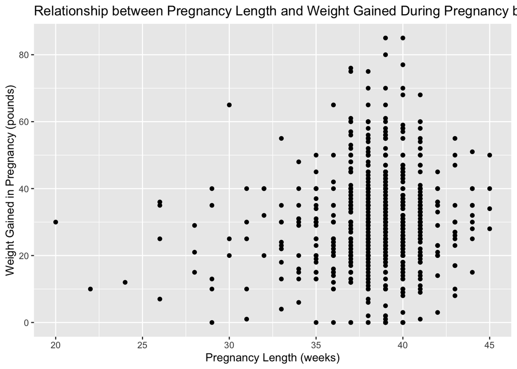

```r
ggplot(data = nc, aes(x=weeks, y = gained)) +
  geom_point() +
  labs( x = "Pregnancy Length (weeks)", y = "Weight Gained in Pregnancy (pounds)", title = "Relationship between Pregnancy Length and Weight Gained During Pregnancy by Pregnant Persons")
```

### Exercise 4

Next I will add a new argument in the above code to indicate values that correspond with a premature birth weight.

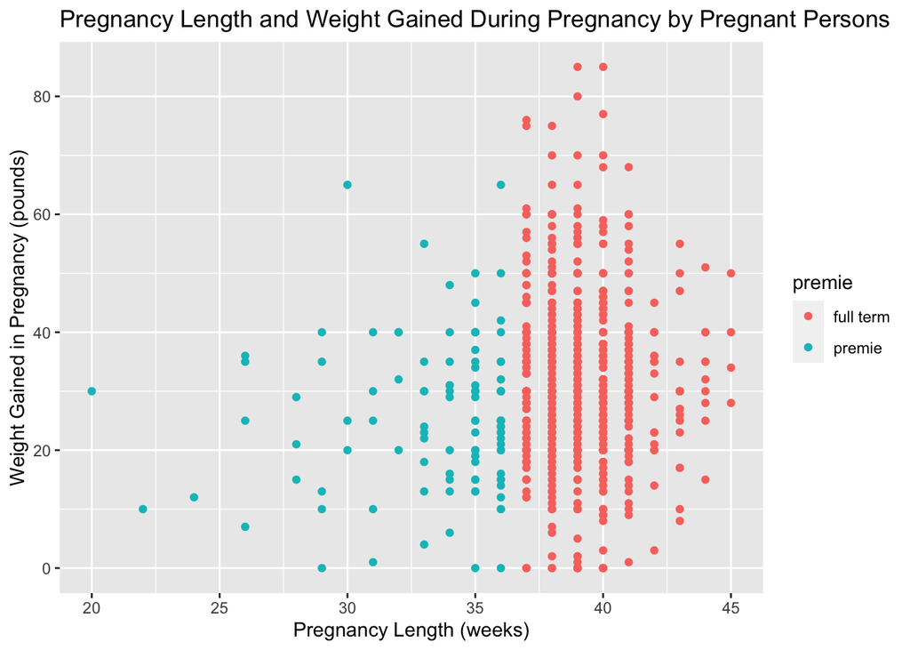

```r
ggplot(data = nc, aes(x=weeks, y = gained, color = premie)) +
  geom_point() +
  labs( x = "Pregnancy Length (weeks)", y = "Weight Gained in Pregnancy (pounds)", title = "Pregnancy Length and Weight Gained During Pregnancy by Pregnant Persons")
```

1. The argument color = premie added colors to data points to distinguish between values with full term versus premature newborn birth weights.
2. Three variables are now displayed, which are premie, weeks, and gained. Premie can be thought of as a binary categorical variable.
3. 36 (and a quarter) weeks is the rough cutoff for when a baby is considered full term or premature. Greater than ~36 is considered full term; less than or equal to ~36 is premature.

### Exercise 5

For this exercise I created a new scatterplot showing mage on the x-axis and birth weight on the y-axis. The plot also includes color based on the newborn’s sex.

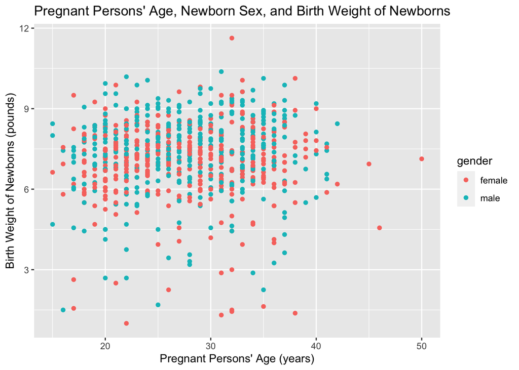

```r
ggplot(data = nc, aes(x=mage, y = weight, color = gender)) +
  geom_point() +
  labs( x = "Pregnant Persons' Age (years)", y = "Birth Weight of Newborns (pounds)", title = "Pregnant Persons' Age, Newborn Sex, and Birth Weight of Newborns")
```

There is not a strong relationship between maternal age and birth weight. Babies that weigh over six pounds seem to have similar frequency between ages 20 and 40, which are also the ages people tend to have children. Below is a second plot showing maternal age, birt hweight of newborns, and premature status.

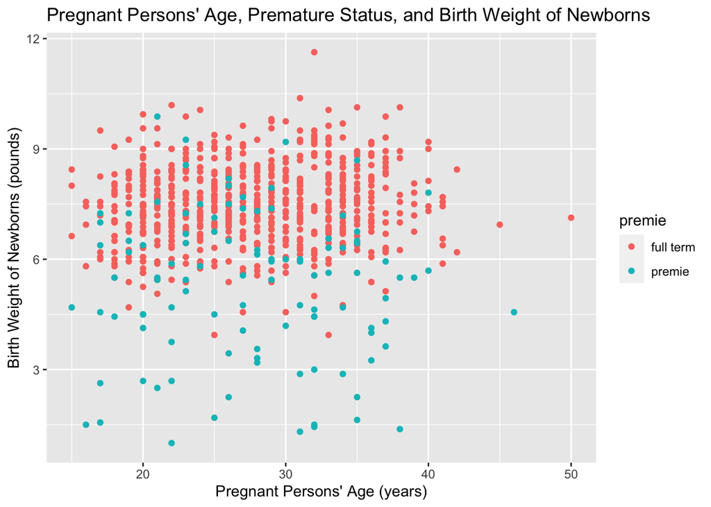

```r
ggplot(data = nc, aes(x=mage, y = weight, color = premie)) +
  geom_point() +
  labs( x = "Pregnant Persons' Age (years)", y = "Birth Weight of Newborns (pounds)", title = "Pregnant Persons' Age, Premature Status, and Birth Weight of Newborns")
```

#### Preparing for Exercises 6 and 7.

In this section I am using histograms to explore distributions of single numerical values. I’ll start with pregnancy duration.

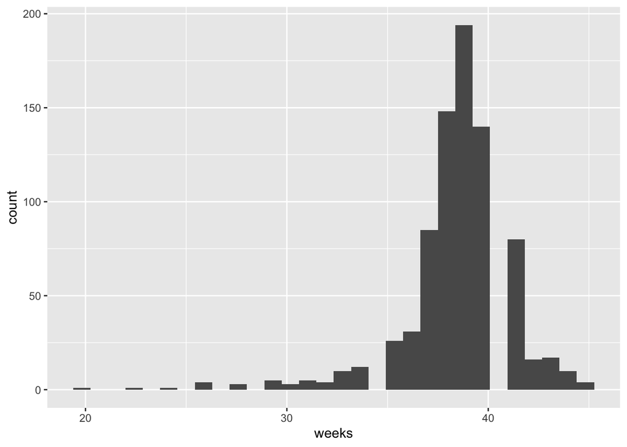

```r
ggplot(data = nc, aes(x=weeks)) +
  geom_histogram()
```

Next I will change bindwidth and colors on the graph.

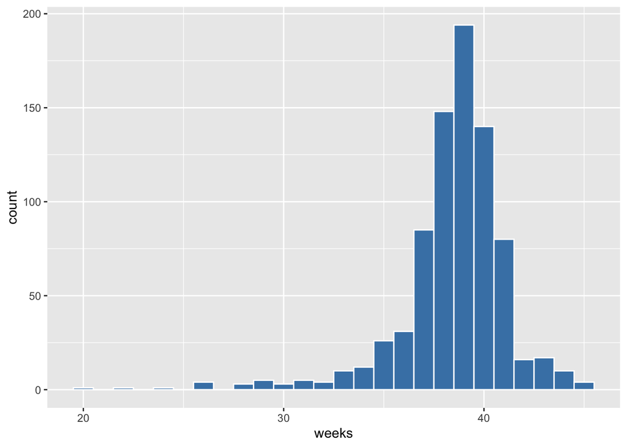

```r
ggplot(data = nc, aes(x = weeks)) +
  geom_histogram(binwidth = 1, color = "white", fill = "steelblue")
```

### Exercise 6

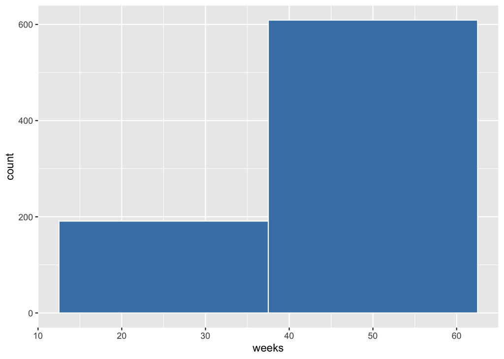

```r
ggplot(data = nc, aes(x = weeks)) +
  geom_histogram(binwidth = 25, color = "white", fill = "steelblue")
```